# Likely Speeders

# 5. Description of Consented, pre-screening sample

## attention checks

| attn_answered_count | n |
| --- | --- |
| 0 | 277 |
| 1 | 44 |
| 2 | 35 |
| 3 | 11 |

table:

| n | q9_pass_n | q9_pass_pct | attn_q9_typo_n | attn_q9_typo_pct | q17_pass_n | q17_pass_pct | q114_pass_n | q114_pass_pct |
| --- | --- | --- | --- | --- | --- | --- | --- | --- |
| 367 | 49 | 13.3515 | 29 | 7.901907 | 43 | 11.71662 | 5 | 1.362398 |

| check | total_n | answered_n | nonanswer_n | pass_n | wrong_n | nonpass_n | answered_pct | pass_pct_all | pass_pct_answered | nonanswer_pct_of_nonpass | wrong_pct_answered |
| --- | --- | --- | --- | --- | --- | --- | --- | --- | --- | --- | --- |
| Q9 | 367 | 90 | 277 | 49 | 41 | 318 | 24.523161 | 13.351499 | 54.44444 | 87.10692 | 45.555556 |
| Q17 | 367 | 46 | 321 | 43 | 3 | 324 | 12.534060 | 11.716621 | 93.47826 | 99.07407 | 6.521739 |
| Q114 | 367 | 11 | 356 | 5 | 6 | 362 | 2.997275 | 1.362398 | 45.45455 | 98.34254 | 54.545455 |

**save that table for overleaf.

| attn_pass_count | attn_answered_count | n |
| --- | --- | --- |
| 0 | 0 | 277 |
| 0 | 1 | 40 |
| 0 | 3 | 1 |
| 1 | 1 | 4 |
| 1 | 2 | 2 |
| 2 | 2 | 33 |
| 2 | 3 | 5 |
| 3 | 3 | 5 |

## duration

what does survey duration actually look like?

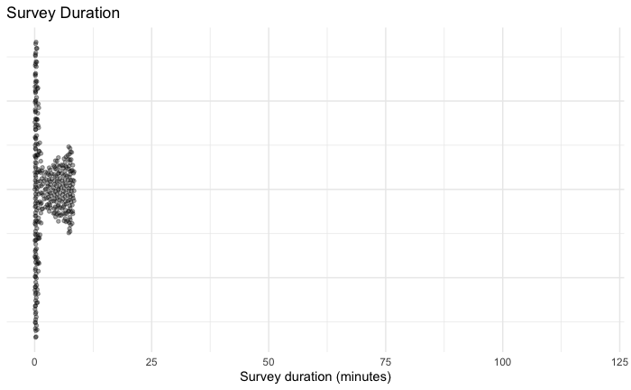

```
   Min. 1st Qu.  Median    Mean 3rd Qu.    Max.
  0.050   0.300   1.683   3.031   5.783   8.417
```

| n | sub_8_n | sub_8_pct | sub_12_n | sub_12_pct | sub_20_n | sub_20_pct | sub_30_n | sub_30_pct | over_52_n | over_52_pct | over_180_n | over_180_pct |
| --- | --- | --- | --- | --- | --- | --- | --- | --- | --- | --- | --- | --- |
| 367 | 367 | 100 | 367 | 100 | 367 | 100 | 367 | 100 | 0 | 0 | 0 | 0 |

## finishers

nonfinisher

| n | finished_n | finished_pct | nonfinished_n | nonfinished_pct |
| --- | --- | --- | --- | --- |
| 367 | 87 | 0.2370572 | 280 | 0.7629428 |

```
  0   1
280  87
```

## missingness?

```
   Min. 1st Qu.  Median    Mean 3rd Qu.    Max.
    2.0   185.0   248.0   208.8   249.0   250.0
   Min. 1st Qu.  Median    Mean 3rd Qu.    Max.
    2.0   185.0   227.0   195.3   227.0   227.0
   Min. 1st Qu.  Median    Mean 3rd Qu.    Max.
   0.00    0.00   21.00   13.53   22.00   23.00
```

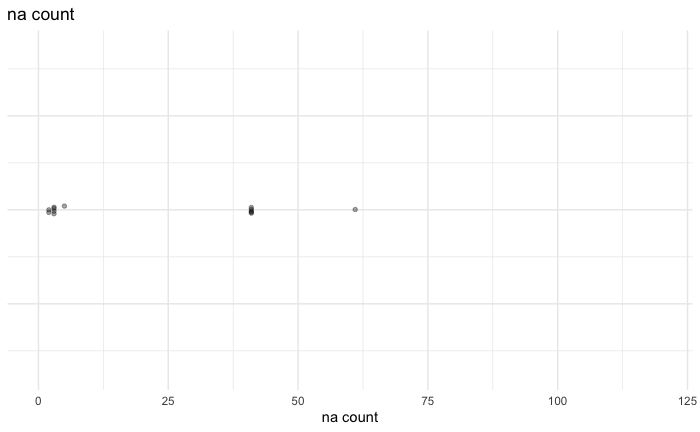

| finished | n | min_na | q1_na | median_na | mean_na | q3_na | max_na |
| --- | --- | --- | --- | --- | --- | --- | --- |
| 0 | 280 | 143 | 248 | 249 | 234.8893 | 249 | 250 |
| 1 | 87 | 2 | 130 | 131 | 124.7931 | 148 | 209 |

| block | n | median_na | mean_na | q75_na | q90_na | max_na |
| --- | --- | --- | --- | --- | --- | --- |
| A | 115 | 209 | 203.1913 | 250 | 250 | 250 |
| B | 123 | 213 | 201.0244 | 248 | 248 | 248 |
| C | 129 | 249 | 221.1860 | 249 | 249 | 249 |

| progress_group | n | median_na | mean_na | min_na | max_na |
| --- | --- | --- | --- | --- | --- |
| 100% | 87 | 131 | 124.7931 | 2 | 209 |
| <25% | 280 | 249 | 234.8893 | 143 | 250 |

## clustering of indicators?

overlap summary

### enough usable measurements?

Ie, did respondents supply enough of the questionnaire to furnish usable measurements?

Among people who broke off—or among finishers with substantial missingness—what analytically important information is actually present?

q15_1 q15_2 q15_3 q15_4 q15_5 q15 q25_1 q25_2 q25_3 q25_4 q25_1 q4_1_1 q4_1_2 q4_1_3 q4_2_1 q4_2_2 q4_2_3

q15_1 q15_2 q15_3 q15_4 q15_5 q15 q25_1 q25_2 q25_3 q25_4 q25_1 q4_1_1 q4_1_2 q4_1_3 q4_2_1 q4_2_2 q4_2_3, q62_1,q51_1, q51_2, q51_3, q51_4, q51_5, q51_6, q51_7, q51_8, dem101,

q32, q33, q34, q35, q36, q37, q38, q111,

used variables

for overleaf

Branch questions: 109 112 dem q53

Demographics q51_n (racial dem) q56 (gender) (_1 is women, _2 man, _3 queer, _4 other)

Info I will need about respondents who answer DVs - race - gender - political identity

Race vars uncleaned are 0, 1, NA, -99

425 not-white respondents who made it to this question 1184 white respondents who made it to this question 1082 started but didn’t make it to this question

268 black respondents 1341 not black respondents 1082 NA

237 Hispanic respondents 1372 not hispanic respondents 1082 NA

# 6. Flag and or drop

### duration

-already did sub 8 through 30, over 52 over 180 Hillygus: standard is to drop 1/3 median, flag 1/2 median